# Predicting functional consequences of recent natural selection in Britain

Lin Poyraz

## Description

This file produces all main figures included in “Predicting functional consequences of recent natural selection in Britain”

## Packages

```r
library(ggplot2)
library(dplyr)
library(data.table)
library(ggpubr)
library(calibrate)
library(scales)
library(ggrepel)
library(gtable)
library(gt)
```

## Functions to make figures and tables

### Functions to make manhattan plots

This is the general manhattan plot function. Edited minimally and adapted from R-package qqman https://rdrr.io/cran/qqman/src/R/manhattan.R

```r
# PACKAGE: qqman https://rdrr.io/cran/qqman/src/R/manhattan.R
manhattan <- function(x, chr="CHR", bp="BP", p="P", snp="SNP",
                      col=c("gray10", "gray60"), chrlabs=NULL,
                      suggestiveline=-log10(1e-5), genomewideline=-log10(5e-8),
                      highlight=NULL, logp=TRUE, annotatePval = NULL, annotateTop = TRUE, ...) {

  par(mar = c(5, 5, 4, 2) + 0.1)
  # Not sure why, but package check will warn without this.
  CHR=BP=P=index=NULL

  # Check for sensible dataset
  ## Make sure you have chr, bp and p columns.
  if (!(chr %in% names(x))) stop(paste("Column", chr, "not found!"))
  if (!(bp %in% names(x))) stop(paste("Column", bp, "not found!"))
  if (!(p %in% names(x))) stop(paste("Column", p, "not found!"))
  ## warn if you don't have a snp column
  if (!(snp %in% names(x))) warning(paste("No SNP column found. OK unless you're trying to highlight."))
  ## make sure chr, bp, and p columns are numeric.
  if (!is.numeric(x[[chr]])) stop(paste(chr, "column should be numeric. Do you have 'X', 'Y', 'MT', etc? If so change to numbers and try again."))
  if (!is.numeric(x[[bp]])) stop(paste(bp, "column should be numeric."))
  if (!is.numeric(x[[p]])) stop(paste(p, "column should be numeric."))

  # Create a new data.frame with columns called CHR, BP, and P.
  # d=data.frame(CHR=x[[chr]], BP=x[[bp]], P=x[[p]], pos = NA, index = NA) # with millions of SNPs, create dataframe at once
  #  rather than dynamically allocated(see line 72-73, and remove line 87 and line 91 )

  # If the input data frame has a SNP column, add it to the new data frame you're creating.
  if (!is.null(x[[snp]])) d = data.frame(CHR=x[[chr]], BP=x[[bp]], P=x[[p]], pos = NA, index = NA ,SNP=x[[snp]], stringsAsFactors = FALSE) else
    d = data.frame(CHR=x[[chr]], BP=x[[bp]], P=x[[p]], pos = NA, index = NA)


  # Set positions, ticks, and labels for plotting
  ## Sort and keep only values where is numeric.
  #d <- subset(d[order(d$CHR, d$BP), ], (P>0 & P<=1 & is.numeric(P)))
  #  d <- subset(d, (is.numeric(CHR) & is.numeric(BP) & is.numeric(P)))       ## unused, all three variables are numeric, line:63-65
  d <- d[order(d$CHR, d$BP), ]
  #d$logp <- ifelse(logp, yes=-log10(d$P), no=d$P)
  if (logp) {
    d$logp <- -log10(d$P)
  } else {
    d$logp <- d$P
  }
  # d$pos=NA


  # Fixes the bug where one chromosome is missing by adding a sequential index column.
  # d$index=NA
  # ind = 0
  # for (i in unique(d$CHR)){
  #     ind = ind + 1
  #     d[d$CHR==i,]$index = ind
  # }
  d$index = rep.int(seq_along(unique(d$CHR)), times = tapply(d$SNP,d$CHR,length))  # replcace the for loop of line 92-96 to improve efficiency

  # This section sets up positions and ticks. Ticks should be placed in the
  # middle of a chromosome. The a new pos column is added that keeps a running
  # sum of the positions of each successive chromsome. For example:
  # chr bp pos
  # 1   1  1
  # 1   2  2
  # 2   1  3
  # 2   2  4
  # 3   1  5
  nchr = length(unique(d$CHR))
  if (nchr==1) { ## For a single chromosome
    ## Uncomment the next two linex to plot single chr results in Mb
    #options(scipen=999)
    #d$pos=d$BP/1e6
    d$pos=d$BP
    #ticks=floor(length(d$pos))/2+1          ## unused, from code line: 169
    xlabel = paste('Chromosome',unique(d$CHR),'position')
    #labs = ticks          ## unused, from code line: 169
  } else { ## For multiple chromosomes
    lastbase=0
    ticks=NULL
    for (i in unique(d$index)) {
      if (i==1) {
        d[d$index==i, ]$pos=d[d$index==i, ]$BP
      } else {
        ## chromosome position maybe not start at 1, eg. 9999. So gaps may be produced.
        lastbase = lastbase +max(d[d$index==(i-1),"BP"])   # replace line 128
        d[d$index == i,"BP"] = d[d$index == i,"BP"]-min(d[d$index==i,"BP"]) +1
        d[d$index == i, "pos"] = d[d$index == i,"BP"] + lastbase    # replace line 129
        # lastbase=lastbase+tail(subset(d,index==i-1)$BP, 1)
        # d[d$index==i, ]$pos=d[d$index==i, ]$BP+lastbase

      }
      # Old way: assumes SNPs evenly distributed
      #ticks=c(ticks, d[d$index==i, ]$pos[floor(length(d[d$index==i, ]$pos)/2)+1])
      # New way: doesn't make that assumption
      ticks = c(ticks, (min(d[d$index == i,]$pos) + max(d[d$index == i,]$pos))/2 + 1)  # see line 136, to reduce the burden of for loop
    }
    #ticks <-tapply(d$pos,d$index,mean)   # replace line 135
    xlabel = 'Chromosome'
    #labs = append(unique(d$CHR),'') ## I forgot what this was here for... if seems to work, remove.
    labs <- unique(d$CHR)
  }

  # Initialize plot
  xmax = ceiling(max(d$pos) * 1.03)
  xmin = floor(max(d$pos) * -0.03)

  # The old way to initialize the plot
  # plot(NULL, xaxt='n', bty='n', xaxs='i', yaxs='i', xlim=c(xmin,xmax), ylim=c(ymin,ymax),
  #      xlab=xlabel, ylab=expression(-log[10](italic(p))), las=1, pch=20, ...)


  # The new way to initialize the plot.
  ## See http://stackoverflow.com/q/23922130/654296
  ## First, define your default arguments
  def_args <- list(xaxt='n', bty='l', xaxs='i', yaxs='i', las=1, pch=20,
                   xlim=c(xmin,xmax), cex.lab=1.3, ylim=c(0,ceiling(max(d$logp))),
                   xlab=xlabel, ylab=expression(-log[10](italic(p))))
  ## Next, get a list of ... arguments
  #dotargs <- as.list(match.call())[-1L]
  dotargs <- list(...)
  ## And call the plot function passing NA, your ... arguments, and the default
  ## arguments that were not defined in the ... arguments.
  do.call("plot", c(NA, dotargs, def_args[!names(def_args) %in% names(dotargs)]))

  # If manually specifying chromosome labels, ensure a character vector and number of labels matches number chrs.
  if (!is.null(chrlabs)) {
    if (is.character(chrlabs)) {
      if (length(chrlabs)==length(labs)) {
        labs <- chrlabs
      } else {
        warning("You're trying to specify chromosome labels but the number of labels != number of chromosomes.")
      }
    } else {
      warning("If you're trying to specify chromosome labels, chrlabs must be a character vector")
    }
  }

  # Add an axis.
  if (nchr==1) { #If single chromosome, ticks and labels automatic.
    axis(1, ...)
  } else { # if multiple chrs, use the ticks and labels you created above.
    axis(1, at=ticks, labels=labs, cex.axis = 0.75, ...)
  }

  # Create a vector of alternatiting colors
  #col=rep(col, max(d$CHR))  # replaced by line 187
  col = rep_len(col, max(d$index))  ## mean this one?  the results are same

  # Add points to the plot
  if (nchr==1) {
    with(d, points(pos, logp, pch=20, col=col[1], ...))
  } else {
    # if multiple chromosomes, need to alternate colors and increase the color index (icol) each chr.
    icol=1
    for (i in unique(d$index)) {
      #with(d[d$index==unique(d$index)[i], ], points(pos, logp, col=col[icol], pch=20, ...))
      points(d[d$index==i,"pos"], d[d$index==i,"logp"], col=col[icol], pch=20, ...)
      icol=icol+1
    }
  }

  # Add suggestive and genomewide lines
  if (suggestiveline) abline(h=suggestiveline, col="blue", lty = 2)
  if (genomewideline) abline(h=genomewideline, col="red", lty = 2)

  # Highlight snps from a character vector
  if (!is.null(highlight)) {
    if (any(!(highlight %in% d$SNP))) warning("You're trying to highlight SNPs that don't exist in your results.")
    d.highlight=d[which(d$SNP %in% highlight), ]
    with(d.highlight, points(pos, logp, col="green3", pch=20, ...))
  }

  # Highlight top SNPs
  if (!is.null(annotatePval)) {
    # extract top SNPs at given p-val
    if (logp) {
      topHits = subset(d, P <= annotatePval)
    } else
      topHits = subset(d, P >= annotatePval)
    par(xpd = TRUE)
    # annotate these SNPs
    if (annotateTop == FALSE) {
      if (logp) {
        with(subset(d, P <= annotatePval),
             textxy(pos, -log10(P), labs = topHits$SNP, cex = 0.45), ...)
      } else
        with(subset(d, P >= annotatePval),
             textxy(pos, P, labs = topHits$SNP, cex = 0.45), ...)
    }
    else {
      # could try alternative, annotate top SNP of each sig chr
      topHits <- topHits[order(topHits$P),]
      topSNPs <- NULL

      for (i in unique(topHits$CHR)) {

        chrSNPs <- topHits[topHits$CHR == i,]
        topSNPs <- rbind(topSNPs, chrSNPs[1,])
        # for selection scan
        #if (i == 5){
        #  topSNPs <- rbind(topSNPs, chrSNPs[4,])
        #}

      #}
      if (logp ){
        # pretty labels
        topSNPs = topSNPs[order(topSNPs$pos, decreasing = FALSE), ]
        #for(r in 1:(nrow(topSNPs)-1)){
         # if(abs(topSNPs$pos[r] - topSNPs$pos[r+1]) < 5e7){
          #  topSNPs$pos[r] = topSNPs$pos[r] - 1e7
           # topSNPs$pos[r+1] = topSNPs$pos[r+1] + 1e7
          #}
        #}
        # for selection scan manhattan
        #topSNPs$SNP = c("LCT", "MANF", "SLC45A2", "PDLIM4", "HLA", "SLC26A5", "SHOC2", "DHCR7", "OAS1", "HERC2", "PAPD5", "NF1", "chr18:41.5Mb", "VAV1")
        y = -log10(topSNPs$P) + 3
        long = which(nchar(topSNPs$SNP) >= 5)
        y[long] = y[long] + 1
        longer = which(nchar(topSNPs$SNP) >= 9)
        y[longer] = y[longer] + 1.3

        textxy(topSNPs$pos, y , labs = topSNPs$SNP, cex = 1, font = 3,srt=90,offset = 0, ...)
      } else
        text(topSNPs$pos, -log10(topSNPs$P) + 0.5,labs = topSNPs$SNP, cex = 0.9, font = 3, srt=90, ...)
    }
  }
  par(xpd = FALSE)
  }
}
```

This is the manhattan plot function edited to annotate gene peaks in the genome-wide selection scan.

```r
# PACKAGE: qqman https://rdrr.io/cran/qqman/src/R/manhattan.R
manhattan_ss <- function(x, chr="CHR", bp="BP", p="P", snp="SNP",
                      col=c("gray10", "gray60"), chrlabs=NULL,
                      suggestiveline=-log10(1e-5), genomewideline=-log10(5e-8),
                      highlight=NULL, logp=TRUE, annotatePval = NULL, annotateTop = TRUE, ...) {

  par(mar = c(5, 5, 4, 2) + 0.1)
  # Not sure why, but package check will warn without this.
  CHR=BP=P=index=NULL

  # Check for sensible dataset
  ## Make sure you have chr, bp and p columns.
  if (!(chr %in% names(x))) stop(paste("Column", chr, "not found!"))
  if (!(bp %in% names(x))) stop(paste("Column", bp, "not found!"))
  if (!(p %in% names(x))) stop(paste("Column", p, "not found!"))
  ## warn if you don't have a snp column
  if (!(snp %in% names(x))) warning(paste("No SNP column found. OK unless you're trying to highlight."))
  ## make sure chr, bp, and p columns are numeric.
  if (!is.numeric(x[[chr]])) stop(paste(chr, "column should be numeric. Do you have 'X', 'Y', 'MT', etc? If so change to numbers and try again."))
  if (!is.numeric(x[[bp]])) stop(paste(bp, "column should be numeric."))
  if (!is.numeric(x[[p]])) stop(paste(p, "column should be numeric."))

  # Create a new data.frame with columns called CHR, BP, and P.
  # d=data.frame(CHR=x[[chr]], BP=x[[bp]], P=x[[p]], pos = NA, index = NA) # with millions of SNPs, create dataframe at once
  #  rather than dynamically allocated(see line 72-73, and remove line 87 and line 91 )

  # If the input data frame has a SNP column, add it to the new data frame you're creating.
  if (!is.null(x[[snp]])) d = data.frame(CHR=x[[chr]], BP=x[[bp]], P=x[[p]], pos = NA, index = NA ,SNP=x[[snp]], stringsAsFactors = FALSE) else
    d = data.frame(CHR=x[[chr]], BP=x[[bp]], P=x[[p]], pos = NA, index = NA)


  # Set positions, ticks, and labels for plotting
  ## Sort and keep only values where is numeric.
  #d <- subset(d[order(d$CHR, d$BP), ], (P>0 & P<=1 & is.numeric(P)))
  #  d <- subset(d, (is.numeric(CHR) & is.numeric(BP) & is.numeric(P)))       ## unused, all three variables are numeric, line:63-65
  d <- d[order(d$CHR, d$BP), ]
  #d$logp <- ifelse(logp, yes=-log10(d$P), no=d$P)
  if (logp) {
    d$logp <- -log10(d$P)
  } else {
    d$logp <- d$P
  }
  # d$pos=NA


  # Fixes the bug where one chromosome is missing by adding a sequential index column.
  # d$index=NA
  # ind = 0
  # for (i in unique(d$CHR)){
  #     ind = ind + 1
  #     d[d$CHR==i,]$index = ind
  # }
  d$index = rep.int(seq_along(unique(d$CHR)), times = tapply(d$SNP,d$CHR,length))  # replcace the for loop of line 92-96 to improve efficiency

  # This section sets up positions and ticks. Ticks should be placed in the
  # middle of a chromosome. The a new pos column is added that keeps a running
  # sum of the positions of each successive chromsome. For example:
  # chr bp pos
  # 1   1  1
  # 1   2  2
  # 2   1  3
  # 2   2  4
  # 3   1  5
  nchr = length(unique(d$CHR))
  if (nchr==1) { ## For a single chromosome
    ## Uncomment the next two linex to plot single chr results in Mb
    #options(scipen=999)
    #d$pos=d$BP/1e6
    d$pos=d$BP
    #ticks=floor(length(d$pos))/2+1          ## unused, from code line: 169
    xlabel = paste('Chromosome',unique(d$CHR),'position')
    #labs = ticks          ## unused, from code line: 169
  } else { ## For multiple chromosomes
    lastbase=0
    ticks=NULL
    for (i in unique(d$index)) {
      if (i==1) {
        d[d$index==i, ]$pos=d[d$index==i, ]$BP
      } else {
        ## chromosome position maybe not start at 1, eg. 9999. So gaps may be produced.
        lastbase = lastbase +max(d[d$index==(i-1),"BP"])   # replace line 128
        d[d$index == i,"BP"] = d[d$index == i,"BP"]-min(d[d$index==i,"BP"]) +1
        d[d$index == i, "pos"] = d[d$index == i,"BP"] + lastbase    # replace line 129
        # lastbase=lastbase+tail(subset(d,index==i-1)$BP, 1)
        # d[d$index==i, ]$pos=d[d$index==i, ]$BP+lastbase

      }
      # Old way: assumes SNPs evenly distributed
      #ticks=c(ticks, d[d$index==i, ]$pos[floor(length(d[d$index==i, ]$pos)/2)+1])
      # New way: doesn't make that assumption
      ticks = c(ticks, (min(d[d$index == i,]$pos) + max(d[d$index == i,]$pos))/2 + 1)  # see line 136, to reduce the burden of for loop
    }
    #ticks <-tapply(d$pos,d$index,mean)   # replace line 135
    xlabel = 'Chromosome'
    #labs = append(unique(d$CHR),'') ## I forgot what this was here for... if seems to work, remove.
    labs <- unique(d$CHR)
  }

  # Initialize plot
  xmax = ceiling(max(d$pos) * 1.03)
  xmin = floor(max(d$pos) * -0.03)

  # The old way to initialize the plot
  # plot(NULL, xaxt='n', bty='n', xaxs='i', yaxs='i', xlim=c(xmin,xmax), ylim=c(ymin,ymax),
  #      xlab=xlabel, ylab=expression(-log[10](italic(p))), las=1, pch=20, ...)


  # The new way to initialize the plot.
  ## See http://stackoverflow.com/q/23922130/654296
  ## First, define your default arguments
  def_args <- list(xaxt='n', bty='l', xaxs='i', yaxs='i', las=1, pch=20,
                   xlim=c(xmin,xmax), cex.lab=1.3, ylim=c(0,ceiling(max(d$logp))),
                   xlab=xlabel, ylab=expression(-log[10](italic(p))))
  ## Next, get a list of ... arguments
  #dotargs <- as.list(match.call())[-1L]
  dotargs <- list(...)
  ## And call the plot function passing NA, your ... arguments, and the default
  ## arguments that were not defined in the ... arguments.
  do.call("plot", c(NA, dotargs, def_args[!names(def_args) %in% names(dotargs)]))

  # If manually specifying chromosome labels, ensure a character vector and number of labels matches number chrs.
  if (!is.null(chrlabs)) {
    if (is.character(chrlabs)) {
      if (length(chrlabs)==length(labs)) {
        labs <- chrlabs
      } else {
        warning("You're trying to specify chromosome labels but the number of labels != number of chromosomes.")
      }
    } else {
      warning("If you're trying to specify chromosome labels, chrlabs must be a character vector")
    }
  }

  # Add an axis.
  if (nchr==1) { #If single chromosome, ticks and labels automatic.
    axis(1, ...)
  } else { # if multiple chrs, use the ticks and labels you created above.
    axis(1, at=ticks, labels=labs, cex.axis = 0.75, ...)
  }

  # Create a vector of alternatiting colors
  #col=rep(col, max(d$CHR))  # replaced by line 187
  col = rep_len(col, max(d$index))  ## mean this one?  the results are same

  # Add points to the plot
  if (nchr==1) {
    with(d, points(pos, logp, pch=20, col=col[1], ...))
  } else {
    # if multiple chromosomes, need to alternate colors and increase the color index (icol) each chr.
    icol=1
    for (i in unique(d$index)) {
      #with(d[d$index==unique(d$index)[i], ], points(pos, logp, col=col[icol], pch=20, ...))
      points(d[d$index==i,"pos"], d[d$index==i,"logp"], col=col[icol], pch=20, ...)
      icol=icol+1
    }
  }

  # Add suggestive and genomewide lines
  if (suggestiveline) abline(h=suggestiveline, col="blue", lty = 2)
  if (genomewideline) abline(h=genomewideline, col="red", lty = 2)

  # Highlight snps from a character vector
  if (!is.null(highlight)) {
    if (any(!(highlight %in% d$SNP))) warning("You're trying to highlight SNPs that don't exist in your results.")
    d.highlight=d[which(d$SNP %in% highlight), ]
    with(d.highlight, points(pos, logp, col="green3", pch=20, ...))
  }

  # Highlight top SNPs
  if (!is.null(annotatePval)) {
    # extract top SNPs at given p-val
    if (logp) {
      topHits = subset(d, P <= annotatePval)
    } else
      topHits = subset(d, P >= annotatePval)
    par(xpd = TRUE)
    # annotate these SNPs
    if (annotateTop == FALSE) {
      if (logp) {
        with(subset(d, P <= annotatePval),
             textxy(pos, -log10(P), labs = topHits$SNP, cex = 0.45), ...)
      } else
        with(subset(d, P >= annotatePval),
             textxy(pos, P, labs = topHits$SNP, cex = 0.45), ...)
    }
    else {
      # could try alternative, annotate top SNP of each sig chr
      topHits <- topHits[order(topHits$P),]
      topSNPs <- NULL

      for (i in unique(topHits$CHR)) {

        chrSNPs <- topHits[topHits$CHR == i,]
        topSNPs <- rbind(topSNPs, chrSNPs[1,])
        # for selection scan
        if (i == 5){
          topSNPs <- rbind(topSNPs, chrSNPs[3,])
        }

      }
      if (logp ){
        # pretty labels
        topSNPs = topSNPs[order(topSNPs$pos, decreasing = FALSE), ]
        #for(r in 1:(nrow(topSNPs)-1)){
         # if(abs(topSNPs$pos[r] - topSNPs$pos[r+1]) < 5e7){
          #  topSNPs$pos[r] = topSNPs$pos[r] - 1e7
           # topSNPs$pos[r+1] = topSNPs$pos[r+1] + 1e7
          #}
        #}
        # for selection scan manhattan
        topSNPs$SNP = c("LCT", "MANF", "SLC45A2", "PDLIM4", "HLA", "SLC26A5", "SHOC2", "DHCR7", "OAS1", "HERC2", "PAPD5", "NF1", "chr18:41.3Mb", "VAV1", "chr21:30.2Mb")
        y = -log10(topSNPs$P) + 3
        long = which(nchar(topSNPs$SNP) >= 5)
        y[long] = y[long] + 1
        longer = which(nchar(topSNPs$SNP) >= 9)
        y[longer] = y[longer] + 1.3

        textxy(topSNPs$pos, y , labs = topSNPs$SNP, cex = 1, font = 3,srt=90,offset = 0, ...)
      } else
        text(topSNPs$pos, -log10(topSNPs$P) + 0.5,labs = topSNPs$SNP, cex = 0.9, font = 3, srt=90, ...)
    }
  }
  par(xpd = FALSE)
  }
```

This function takes in outputs from time_series_regression.R annotated with imputation qualities with imputation_results.R and turns them into MH_df format, which is the input format for our Manhattan plot functions. This function filters out the genes with the lowest 20% imputation scores, performs GC, FDR and Bonferroni correction.

```r
# Returns regression results file in MH_df format
to_MH_df = function(results){
  # filter for imputation quality, first remove those without quality values
  results = results[which(!is.na(results$Mean.Imputation.Rsq)),]
  # then remove lowest 20% for imputation quality
  results = results[which(results$Mean.Imputation.Rsq > quantile(results$Mean.Imputation.Rsq, 0.2)),]
  # now, add GC, FDR and Bonferroni
  p = results$P.value
  chi_stat = qchisq(p, df = 1, lower.tail=F)
  lambda = median(chi_stat)/qchisq(0.5, df=1) #inflation factor
  corrected_p = pchisq(chi_stat/lambda, df=1, lower.tail=F)
  results$GC = corrected_p
  results$FDR = p.adjust(corrected_p, method = "fdr")
  results$Bonferroni = p.adjust(corrected_p, method = "bonferroni")
  # convert to MH format
  df = data.frame("CHR" = rep(NA, nrow(results)), "POS" = rep(NA, nrow(results)), "PVAL" = rep(NA, nrow(results)))
  # Set values for df
  df$CHR = gsub(results$chr, pattern = "chr", replacement = "")
  df$POS = round((results$start + results$end) / 2)
  df$START = results$start
  df$END = results$end
  df$PVAL = results$GC
  df$Gene = results$Gene
  df$CHR = as.numeric(df$CHR)
  df$BETA = results$Beta
  df$FDR = results$FDR
  df$RAW = p
  df$Ensembl = results$Ensembl
  return(df)
}
```

This function returns FDR and Bonferroni cutoffs from MH_df files to input into the manhattan plot functions.

```r
# Returns FDR and Bonferroni cutoffs from MH_df file
cutoffs = function(df){
  # find sig FDR cutoff
  FDR = p.adjust(df$PVAL, "fdr")
  i = which(FDR <= 0.05)
  fdr_cut = max(df$PVAL[i])
  # find sig bonferroni cutoff
  b = p.adjust(df$PVAL, "bonferroni")
  i = which(b <= 0.05)
  b_cut = max(df$PVAL[i])
 return(c(fdr_cut, b_cut))
}
```

### Functions to combine GWSS and TWSS results

This function generates a list of selected regions from selection scan by combining consecutive (<5e6 bp apart) FDR-significant windows. It adds 1e5 bp buffers to each “consecutive region under selection.”

```r
find_under_selection = function(selection, fdr_cutoff){
  i = 1
  under_selection = data.frame("chr" = "a", "start" = 0, "end" = 0)
  # scan across selection scan file
  while (i < nrow(selection)){
    # if a region is under selection (p value is < fdr cutoff)
    if (selection$P1[i] <= fdr_cutoff){
      # start
      start = selection$start[i]
      j = i + 1
      # if the consecutive regions are also significant
      while (j < nrow(selection) & selection$P1[j] <= fdr_cutoff) {
        j = j + 1
      }
      end = selection$start[j]
      # add to under selection
      if (selection$CHR[i] != selection$CHR[j]){
        print("error")
      }
      under_selection = rbind(under_selection, data.frame("chr" = selection$CHR[i], "start" = start, "end" = end))
      i = j
    } else {
      i = i + 1
    }
  }
  under_selection = under_selection[2:nrow(under_selection),]
  consecutive_under_selection = data.frame("chr" = "a", "start" = 0, "end" = 0)

  # extract consecutive regions under selection
  for (i in unique(under_selection$chr)){
    pos = sort(c(under_selection$start[which(under_selection$chr == i)], under_selection$end[which(under_selection$chr == i)]))
    k = 1
    while (k < length(pos)){
      j = length(pos)
      while (pos[j] - pos[k] > 5e6 & j > k){
        j = j - 1
      }
      consecutive_under_selection = rbind(consecutive_under_selection, data.frame("chr" = i, "start" = pos[k], "end" = pos[j]))
      k = j + 1
    }
  }
  consecutive_under_selection = consecutive_under_selection[2:nrow(consecutive_under_selection),]

    # add 1e5 buffers
  consecutive_under_selection$start = consecutive_under_selection$start - 1e5
  consecutive_under_selection$end = consecutive_under_selection$end + 1e5

  return(consecutive_under_selection)
}
```

Functions to create combined selection scan and expression time-series plots.

```r
# This function creates manhattan plot backdrop for the segment plots
segment_manhattan_plot = function(selection_scan, chr, start_end, p, main, fdr_cutoff, b_cutoff){
  manhattan(subset(selection_scan, CHR == chr), ylim = p, xlim = start_end, chr = "CHR", bp = "POS", snp = "lead.snp", p = "P1", suggestiveline = -log10(fdr_cutoff), genomewideline = -log10(b_cutoff), cex = 0.001, main = main)
  subset_segments = subset(selection_scan, CHR == chr)
  segments(x0 = subset_segments$start, y0 = -log10(subset_segments$P1), x1 = subset_segments$end, lwd = 4, col = "black")
}

# selection_scan: hg38 selection scan results file
# df: hg38 time series regression results file in MH_df format
# start_end = c(start position for manhattan plot, end position for manhattan plot)
# fdr_cutoff, b_cutoffs are horizontal lines
# main is the title of the plot
scan_regression_overlap = function(selection_scan, df, chr, start_end, fdr_cutoff, b_cutoff, main){
  subset_scan = subset(selection_scan, CHR == chr & POS >= start_end[1] & POS <= start_end[2])
  subset = subset(df, CHR == chr & START >= start_end[1] & END <= start_end[2])
  p_cut = max(c(-log10(b_cutoff), max(-log10(subset_scan$P1)), max(-log10(subset$PVAL))), na.rm = T) + 5
  segment_manhattan_plot(selection_scan, chr, start_end, c(0,p_cut), main, fdr_cutoff, b_cutoff)
  if (nrow(subset) > 0){
    color = ifelse(subset$BETA > 0, yes = ifelse(subset$PVAL <= fdr_cutoff, yes = "red", no = alpha("gray", 0.6)), no = ifelse(subset$PVAL <= fdr_cutoff, yes = "blue", no = alpha("gray", 0.6)))
    color_text = ifelse(subset$BETA > 0, yes = ifelse(subset$PVAL <= fdr_cutoff, yes = "red", no = "gray27"), no = ifelse(subset$PVAL <= fdr_cutoff, yes = "blue", no = "gray27"))
    shape = ifelse(subset$BETA > 0, yes = 24, no = 25)
    points(x = subset$POS, y = -log10(subset$PVAL), pch = shape, col = color, bg = color, cex = 4)
    text(x = subset$POS, y = -log10(subset$PVAL), labels = subset$Gene, cex = 1.2, offset = 1.45, pos = 3, col = color_text, font = 3)
  }
}
```

### Functions to visualize expression changes across time

Function to plot expression against time.

```r
# Reads in the expression file of given gene and plots expression against time.
# Note that expression files must be generated beforehand using ./analysis/expression_time_series/sig_genes.R
expression_plot = function(gene){
  gene_df = read.table(paste("./data/expression/", gene, ".txt.gz", sep = ""), header = T, sep = "\t")
  gene_df = na.omit(gene_df)
  p = ggplot(data = gene_df, aes(x = time, y = gene)) + geom_point(size = 1.3) + theme_bw() + theme(text = element_text(size = 15))+ labs(y = "Predicted expression", x = "Time", title = gene) +
    scale_color_gradient(low = "black", high = "black") + geom_smooth(method = "lm", color = "blue") + lims(y = c(-2.5, 2.5)) + theme(legend.position = "none",  plot.title=element_text(face="italic"))
  return(p)
}
```

Functions to create allele frequency against time plots.

```r
# Calculates change in time of each snp (beta in snp ~ time), Ensures that all alleles are trait increasing
allele_freq_paper = function(gene){
    gene_df = read.table(paste("./data/allele_frequency/", gene, ".txt.gz", sep = ""), header = T, sep = "\t")
    weights = read.table(paste("./data/allele_frequency/", gene, "_weights.txt.gz", sep = ""), header = T, sep = "\t")
    expression = read.table(paste("./data/expression/", gene, ".txt.gz", sep = ""), header = T, sep = "\t")
  joint = merge(gene_df, expression, by = "iid")
  gene_df$time = as.numeric(gene_df$time)
  num_snp = ncol(gene_df) - 2
  af_df = data.frame(SNP = colnames(gene_df)[1:num_snp], time_beta = rep(NA, num_snp))
  for (i in 1:num_snp){
    # make all trait increasing
    snp = colnames(gene_df)[i]
    weight = weights$weight[which(weights$rsid == snp)]
    m_df = gene_df[,c(i, which(colnames(gene_df) == "time"))]
    names(m_df) = c("snp", "time")
     if (weight < 0){
      m_df$snp = 2 - m_df$snp
    }
    m = summary(lm(snp ~ time, data = m_df))$coefficients["time", "Estimate"]
    af_df$time_beta[i] = m
  }
  return(af_df)
}

af_plot_paper = function(gene){
  weights = read.table(paste("./data/allele_frequency/", gene, "_weights.txt.gz", sep = ""), header = T, sep = "\t")
  af_df = allele_freq_paper(gene)
  af_df$beta - rep(1000, nrow(af_df))
  af_df$dire = rep(NA, nrow(af_df))
  for (i in 1:nrow(af_df)){
    j = which(weights$rsid == af_df$SNP[i])
    af_df$beta[i] = abs(as.numeric(weights$weight[j]))
    if ((af_df$beta[i] * af_df$time_beta[i]) > 0){
      af_df$dire[i] = "up"
    } else {
      af_df$dire[i] = "down"
    }
  }
  p = ggplot(data = af_df, aes(x = beta, y = time_beta, fill = dire, color = dire, shape = dire, label = SNP)) + geom_point(size = 2.5) + theme_bw() +
    scale_color_manual(breaks = c("down", "up"), values = c("blue", "red")) + labs(x = "Effect on normalized expression", y = "Average change in frequency per-year", fill = "SNP", title = gene) + geom_hline(yintercept = 0, linetype = "dashed") + geom_vline(xintercept = 0, linetype = "dashed") + coord_cartesian(xlim = c(0, 1.7), ylim = c(-3e-4, 3e-4)) +
    theme(legend.position = "none", plot.title=element_text(face="italic")) + scale_shape_manual(values = c("up" = 24, "down" = 25)) + scale_fill_manual(breaks = c("down", "up"), values = c("blue", "red"))
  return(p)
}
```

## Figure 1

We begin by preparing the data:

```r
# Read in imputation qualities:
imp_qualities = read.table("./data/imputation_results.txt.gz", header = T, sep = "\t")
imp_scores = imp_qualities[,c("Gene", "Mean.Imputation.Rsq")]
# Read in output from time_series_regression limited to samples with >0.01 coverage
samples_01 = read.table("./data/samples01_time_series_regression_results.txt.gz", header = T)
# Populate output with imputation quality scores
samples_01$Mean.Imputation.Rsq = NA
for (i in 1:nrow(samples_01)){
  g = which(imp_scores$Gene == samples_01$Gene[i])[1]
  samples_01$Mean.Imputation.Rsq[i] = imp_scores$Mean.Imputation.Rsq[g]
}
MH_df_whole = to_MH_df(samples_01)
r_fdr_cut = cutoffs(MH_df_whole)[1]
r_b_cut = cutoffs(MH_df_whole)[2]

# Read in randomized p-values
random  = read.table("./data/samples01_random_time_series_regression_results.txt.gz", header = T, sep = "\t")
random = random[,c("Ensembl", "P.value")]
names(random) = c("Ensembl", "Random.P.value")
# merge randomized and non-randomized data frames on Ensembl gene names
qq_regression = MH_df_whole[c("Ensembl", "RAW", "PVAL")]
merged_twss = merge(random, qq_regression, by = "Ensembl")

# Read in selection scan and identify regions under selection.
selection_scan = read.table("./data/s_scan_all_brit2_01_window.txt.gz", header = T, sep = "\t")

# Read in randomized p-values from selection scan
random_selection_scan = read.table("./data/s_scan_all_brit2_01_random_window.txt.gz", header = T, sep = "\t")
```

We plot the Manhattan plot for the transciptome-wide selection scan (TWSS).

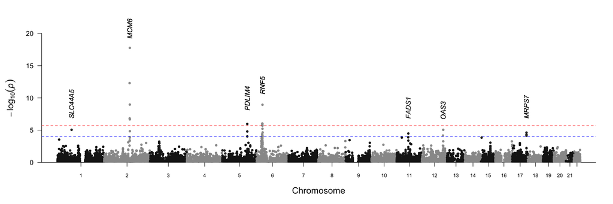

```r
manhattan(MH_df_whole, ylim = c(0,20), chrlabs = as.character(1:22), chr = "CHR", bp = "POS", snp = "Gene", p = "PVAL", annotatePval = r_fdr_cut, suggestiveline = -log10(r_fdr_cut), genomewideline = -log10(r_b_cut))
```

We generate a qq-plot for the TWSS.

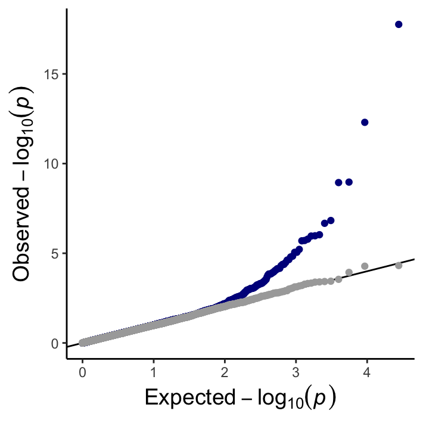

```r
p_results = as.numeric(merged_twss$RAW)
p_random = as.numeric(merged_twss$Random.P.value)
p_GC = as.numeric(merged_twss$PVAL)
observed_results = -log10(sort(p_results))
observed_random = -log10(sort(p_random))
observed_GC = -log10(sort(p_GC))
expected = -log10(ppoints(length(p_results)))

df = data.frame("GC.Observed" = observed_GC, "Randomized" = observed_random, "Expected" = expected)
qqlot = ggplot(data = df, aes(x = Expected, y = GC.Observed)) +
  geom_point(color = "darkblue") + geom_abline(intercept = 0, slope = 1) + labs(cex = 1.4, y = expression("Observed"-log[10](italic(p))), x = expression("Expected"-log[10](italic(p))))+ theme_bw() +
  geom_point(data = df, aes(x = Expected, y = Randomized),color = "darkgray") + theme(axis.line = element_line(colour = "black"),
    axis.title=element_text(size=14),
    panel.grid.major = element_blank(),
    panel.grid.minor = element_blank(),
    panel.border = element_blank(),
    panel.background = element_blank())
qqlot
```

We plot the Manhattan plot for the genome-wide selection scan (GWSS).

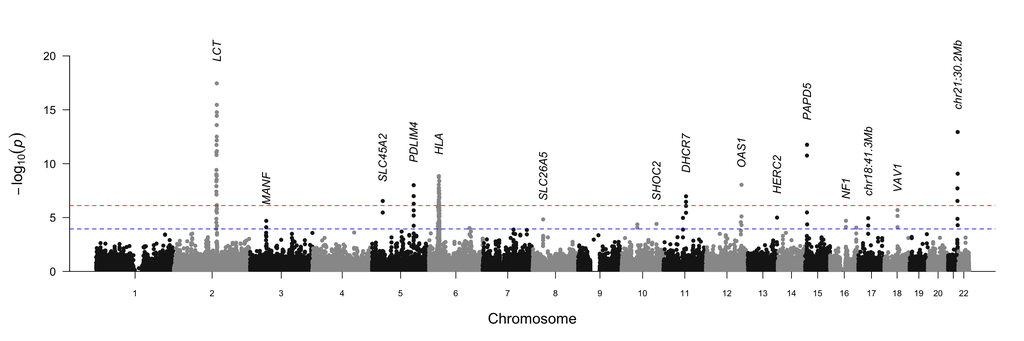

```r
# find sig FDR cutoff
FDR = p.adjust(selection_scan$P1, "fdr")
i = which(FDR <= 0.05)
scan_fdr_cut = max(selection_scan$P1[i])
# find sig bonferroni cutoff
b = p.adjust(selection_scan$P1, "bonferroni")
i = which(b <= 0.05)
scan_b_cut = max(selection_scan$P1[i])
manhattan_ss(selection_scan, ylim = c(0,20), chrlabs = as.character(1:22), chr = "CHR", bp = "POS", snp = "lead.snp", p = "P1", annotatePval = scan_fdr_cut, logp = T, suggestiveline = -log10(scan_fdr_cut), genomewideline = -log10(scan_b_cut))
```

We generate a qq-plot for the GWSS.

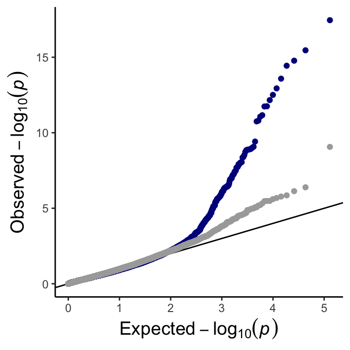

```r
p_random = as.numeric(random_selection_scan$P2)
p_GC = as.numeric(selection_scan$P1)
observed_random = -log10(sort(p_random))
observed_GC = -log10(sort(p_GC))
expected = -log10(ppoints(length(p_random)))
df = data.frame("GC.Observed" = observed_GC, "Randomized" = observed_random, "Expected" = expected)

qqlot = ggplot(data = df, aes(x = Expected, y = GC.Observed)) +
  geom_point(color = "darkblue") + geom_abline(intercept = 0, slope = 1) + labs( y = expression("Observed"-log[10](italic(p))), x = expression("Expected"-log[10](italic(p))))+ theme_bw() +
  geom_point(data = df, aes(x = Expected, y = Randomized),color = "darkgray") + theme(axis.line = element_line(colour = "black"),
    axis.title=element_text(size=14),
    panel.grid.major = element_blank(),
    panel.grid.minor = element_blank(),
    panel.border = element_blank(),
    panel.background = element_blank())
qqlot
```

## Tables 1 & 2

We begin by Table 2, as Table 1 depends on the outputs of this process.

We identify consecutive regions under selection, and add gene information to each selected region. For each selected region, we include genes that start and have a midpoint within the bounds of the selected region (including buffers).

```r
results_whole = samples_01 # results before filtering for imputation quality
results_whole$pos = round((results_whole$start + results_whole$end)/2)
results_whole$chr = gsub(pattern = "chr", replacement ="", results_whole$chr)
# We identify consecutive genes under selection
selection_to_gene = find_under_selection(selection_scan, scan_fdr_cut)
# This is for the purpose of counting all protein coding genes in the region, and the number for which we have models (meaning that they were not filtered out due to low imputation quality)
selection_to_gene$sig_genes = NA
selection_to_gene$all_genes_modeled_num = NaN
selection_to_gene$all_genes_num = NaN
selection_to_gene$sig_genes_num = NaN
for (i in 1:nrow(selection_to_gene)){
  # select genes that start and have a midpoint within the bounds of the selected region
  all_genes = results_whole[which(results_whole$chr == selection_to_gene$chr[i] & results_whole$start >= selection_to_gene$start[i] & results_whole$pos <= selection_to_gene$end[i]),]
  all_genes_modeled = MH_df_whole[which(MH_df_whole$CHR == selection_to_gene$chr[i] & MH_df_whole$START >= selection_to_gene$start[i] & MH_df_whole$POS <= selection_to_gene$end[i]),]
  selection_to_gene$all_genes_modeled_num[i] = nrow(all_genes_modeled)
  selection_to_gene$all_genes_num[i] = nrow(all_genes)
  sig_genes = all_genes_modeled[which(all_genes_modeled$FDR < 0.05),]
  selection_to_gene$sig_genes[i] = paste(sig_genes$Gene, collapse = ", ")
  selection_to_gene$sig_genes_num[i] = nrow(sig_genes)
}
```

We then generate Table 2:

```r
selection_to_gene$chr = as.numeric(selection_to_gene$chr)
selection_to_gene$start = as.numeric(selection_to_gene$start)
selection_to_gene = selection_to_gene[order(selection_to_gene$chr, selection_to_gene$start),]
selection_to_gene_tbl = gt(data = selection_to_gene) %>% cols_label(
    chr = html("Chr"),
    start = html("GWSS Start"),
    end = html("GWSS End"),
    sig_genes = html("TWSS Significant Genes"),
    all_genes_num = "# All Genes",
    all_genes_modeled_num = "# All Modeled Genes",
    sig_genes_num = "# Significant Genes")

selection_to_gene_tbl
```

| Chr | GWSS Start | GWSS End | TWSS Significant Genes | # All Modeled Genes | # All Genes | # Significant Genes |
| --- | --- | --- | --- | --- | --- | --- |
| 2 | 134292811 | 136385296 | MCM6, LCT, DARS, CXCR4, TMEM163, MAP3K19 | 11 | 12 | 6 |
| 3 | 50849763 | 51387494 |  | 1 | 1 | 0 |
| 5 | 33777346 | 34069589 |  | 2 | 4 | 0 |
| 5 | 132101060 | 132454548 | P4HA2, PDLIM4, SLC22A5 | 5 | 5 | 3 |
| 6 | 28140757 | 33178885 | PPP1R18, TUBB, HLA-DMA, PBX2, RNF5, APOM, CCHCR1, CDSN, PSORS1C1, ATF6B, HLA-DPA1, C4A | 148 | 148 | 12 |
| 6 | 128796160 | 129062458 |  | 0 | 0 | 0 |
| 8 | 33218070 | 33438568 |  | 1 | 1 | 0 |
| 10 | 49643164 | 50348209 |  | 5 | 7 | 0 |
| 10 | 110778270 | 111086977 |  | 4 | 4 | 0 |
| 11 | 61684455 | 61903876 | FADS1 | 6 | 6 | 1 |
| 11 | 71302258 | 71592390 |  | 4 | 7 | 0 |
| 12 | 110796571 | 113044151 | OAS3, FAM109A | 17 | 21 | 2 |
| 13 | 111558732 | 111786334 |  | 0 | 0 | 0 |
| 15 | 27951279 | 29045218 |  | 1 | 5 | 0 |
| 16 | 49972683 | 50325572 |  | 2 | 4 | 0 |
| 16 | 82983756 | 83190020 |  | 0 | 0 | 0 |
| 17 | 30984555 | 31423638 |  | 4 | 4 | 0 |
| 18 | 41362995 | 41666874 |  | 0 | 0 | 0 |
| 21 | 43286434 | 44295140 |  | 11 | 12 | 0 |

We identify consecutive selected regions for each FDR significant gene. Genes start and have a midpoint within the bounds of the selected region (including buffers).

```r
fdr_sig = MH_df_whole[which(MH_df_whole$FDR < 0.05), ]
gene_to_selection_scan = data.frame("Chr" = fdr_sig$CHR, "Start" = fdr_sig$START, "End" = fdr_sig$END,
                                    "Position" = fdr_sig$POS, "Gene" = fdr_sig$Gene,
                                    "GC_P" = fdr_sig$PVAL,
                                    "Beta" = fdr_sig$BETA, "GWSS_Start" = NA, "GWSS_End" = NA)
for (i in 1:nrow(gene_to_selection_scan)){
  j = which(gene_to_selection_scan$Chr[i] == selection_to_gene$chr & gene_to_selection_scan$Start[i] >= selection_to_gene$start & gene_to_selection_scan$Position[i] <= selection_to_gene$end)
  if (length(j) > 1){
    print("ERROR, two matches")
  } else if (length(j) == 0) {
    gene_to_selection_scan$GWSS_Start[i] = 0
    gene_to_selection_scan$GWSS_End[i] = 0
  } else {
    gene_to_selection_scan$GWSS_Start[i] = selection_to_gene$start[j]
    gene_to_selection_scan$GWSS_End[i] = selection_to_gene$end[j]
  }
}
```

Next, we add tissue information for each gene.

```r
# Add tissue information to gene_to_selection_scan
# read in tissue information
model_info = read.table("./data/model_info.txt.gz", header = T)
# make tissue pretty
model_info$tissue = gsub(pattern = "_", replace = " ", x = model_info$tissue)
gene_to_selection_scan$Tissue = NA
# then, add in tissue information to gene_to_selection_scan
for (i in 1:nrow(gene_to_selection_scan)){
  j = which(model_info$genename == gene_to_selection_scan$Gene[i])
  if(gene_to_selection_scan$Gene[i] == "FAM109A"){
      j = which(model_info$genename == "PHETA1") #these genes are the same, but have different aliases across these two datasets
  }
   gene_to_selection_scan$Tissue[i] = model_info$tissue[j]
}
```

We then add loci names to the corresponding selected regions for each gene.

```r
# list of loci
gwss_loci = selection_to_gene[which(selection_to_gene$sig_genes_num != 0),]
gwss_loci$locus = c("LCT", "PDLIM4", "HLA", "FADS1", "OAS")
# Add GWSS Peak to gene_to_selection_scan
gene_to_selection_scan$GWSS_Peak = NA
for (i in 1:nrow(gene_to_selection_scan)){
  chr = gene_to_selection_scan$Chr[i]
  start = gene_to_selection_scan$GWSS_Start[i]
  end = gene_to_selection_scan$GWSS_End[i]
  pos = (start+end)/2
  j = which(gwss_loci$chr == chr & gwss_loci$start <= start & gwss_loci$end >= pos)
  if (length(j) != 0){
    gene_to_selection_scan$GWSS_Peak[i] = gwss_loci$locus[j]
  } else {
      gene_to_selection_scan$GWSS_Peak[i] = "Novel"
    }
}
```

We then generate Table 1:

```r
gene_to_selection_scan = gene_to_selection_scan[order(gene_to_selection_scan$Chr, gene_to_selection_scan$Start),]
gene_to_selection_scan$GC_P = signif(gene_to_selection_scan$GC_P, 4)
gene_to_selection_scan$Beta = signif(gene_to_selection_scan$Beta, 4)
# which to italicize in the GWSS signal row
ital_gwss =
# Create .tex tables for gene_to_selection_scan and selection_scan_to_gene
gene_to_selection_scan_tbl = gt(data = gene_to_selection_scan[,c("Chr", "Gene", "Tissue","GC_P", "Beta", "GWSS_Peak")]) %>% cols_label(
    GC_P = "P-value",
    GWSS_Peak = "GWSS Peak"
  ) %>% tab_style(
    style = cell_text(style = "italic"),
    locations = cells_body(
      columns = "Gene"
    )
  )

gene_to_selection_scan_tbl
```

| Chr | Gene | Tissue | P-value | Beta | GWSS Peak |
| --- | --- | --- | --- | --- | --- |
| 1 | SLC44A5 | Skin Sun Exposed Lower leg | 8.827e-06 | -1.178e-04 | Novel |
| 2 | TMEM163 | Kidney Cortex | 5.012e-13 | 1.400e-04 | LCT |
| 2 | MAP3K19 | Testis | 1.490e-07 | 1.127e-04 | LCT |
| 2 | LCT | Cells EBV-transformed lymphocytes | 1.078e-09 | 8.239e-05 | LCT |
| 2 | MCM6 | Esophagus Muscularis | 1.736e-18 | -1.795e-04 | LCT |
| 2 | DARS | Whole Blood | 2.137e-07 | -9.886e-05 | LCT |
| 2 | CXCR4 | Adrenal Gland | 1.457e-05 | -4.051e-05 | LCT |
| 5 | P4HA2 | Thyroid | 9.358e-05 | 1.027e-04 | PDLIM4 |
| 5 | PDLIM4 | Brain Cortex | 1.098e-06 | -4.210e-05 | PDLIM4 |
| 5 | SLC22A5 | Cells Cultured fibroblasts | 1.605e-05 | -1.283e-04 | PDLIM4 |
| 6 | PPP1R18 | Artery Aorta | 4.166e-05 | -2.423e-05 | HLA |
| 6 | TUBB | Cells EBV-transformed lymphocytes | 1.635e-06 | 4.196e-05 | HLA |
| 6 | PSORS1C1 | Thyroid | 7.309e-05 | -7.907e-05 | HLA |
| 6 | CDSN | Skin Sun Exposed Lower leg | 4.200e-05 | 4.507e-05 | HLA |
| 6 | CCHCR1 | Spleen | 9.258e-07 | 8.014e-05 | HLA |
| 6 | APOM | Testis | 1.935e-06 | -2.599e-05 | HLA |
| 6 | C4A | Brain Cerebellum | 2.017e-06 | -8.152e-05 | HLA |
| 6 | ATF6B | Brain Spinal cord cervical c-1 | 6.076e-06 | -5.952e-05 | HLA |
| 6 | RNF5 | Colon Transverse | 1.145e-09 | -6.436e-05 | HLA |
| 6 | PBX2 | Whole Blood | 1.059e-06 | -3.343e-05 | HLA |
| 6 | HLA-DMA | Cells Cultured fibroblasts | 8.493e-05 | 5.442e-05 | HLA |
| 6 | HLA-DPA1 | Cells Cultured fibroblasts | 2.249e-05 | -1.380e-04 | HLA |
| 11 | FADS1 | Brain Cerebellum | 3.310e-05 | 6.236e-05 | FADS1 |
| 12 | FAM109A | Kidney Cortex | 6.886e-05 | -1.752e-05 | OAS |
| 12 | OAS3 | Cells Cultured fibroblasts | 8.779e-06 | -1.264e-04 | OAS |
| 17 | NUP85 | Brain Cerebellar Hemisphere | 7.025e-05 | 1.011e-04 | Novel |
| 17 | GGA3 | Breast Mammary Tissue | 4.907e-05 | 3.052e-05 | Novel |
| 17 | MRPS7 | Brain Cerebellar Hemisphere | 2.420e-05 | -3.548e-05 | Novel |

## Figure 2

We plot TWSS-GWSS overlap plots for each significant locus.

FADS region

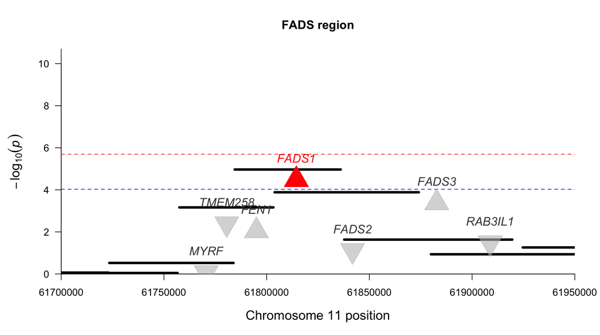

```r
scan_regression_overlap(selection_scan, MH_df_whole, 11, c(61700000, 61950000), r_fdr_cut, r_b_cut, "FADS region")
```

HLA region

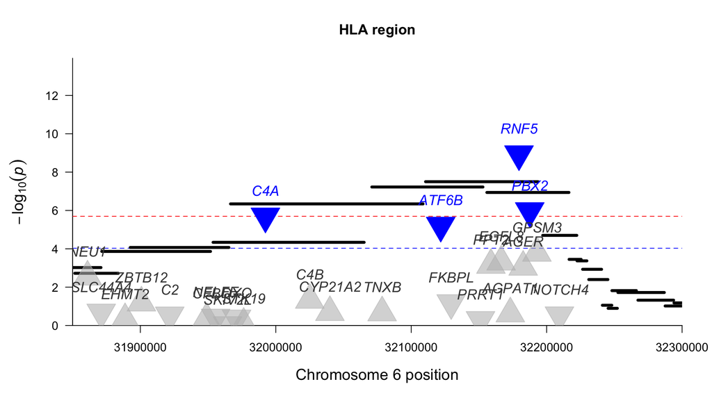

```r
scan_regression_overlap(selection_scan, MH_df_whole, 6, c(31850000, 32300000), r_fdr_cut, r_b_cut, "HLA region")
```

LCT region

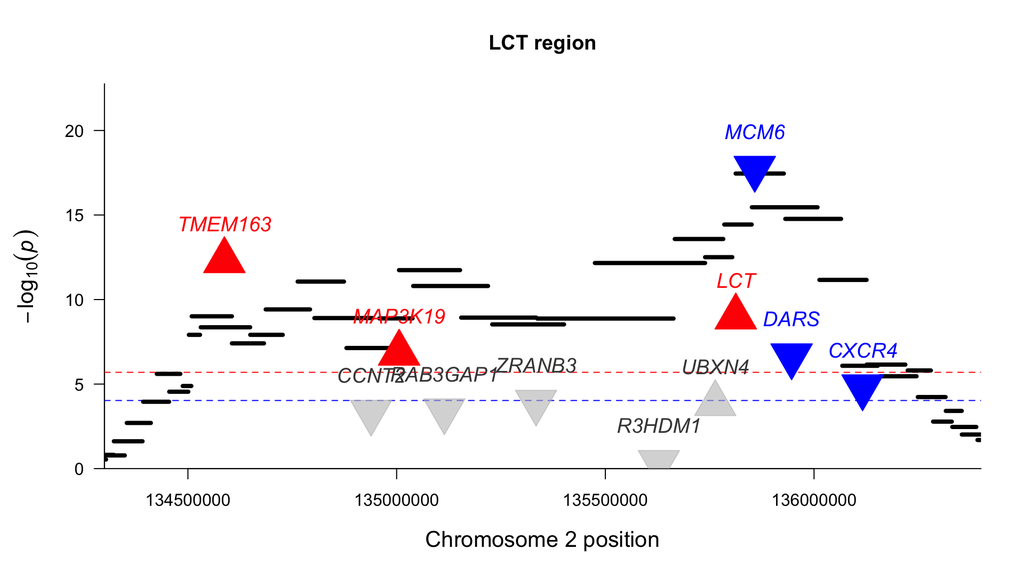

```r
scan_regression_overlap(selection_scan, MH_df_whole, 2, c(134300000, 136400000), r_fdr_cut, r_b_cut, "LCT region")
```

OAS region

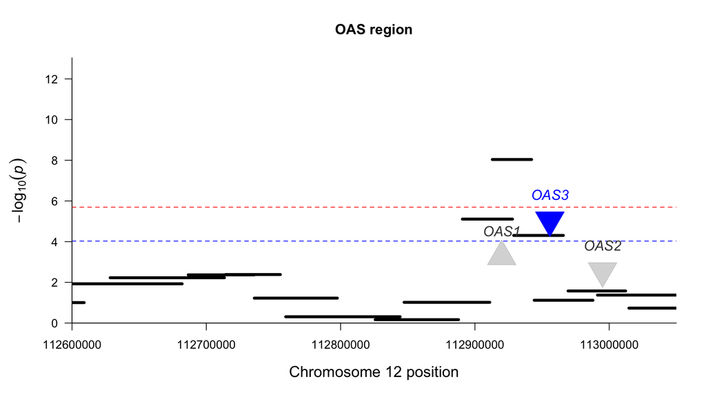

```r
scan_regression_overlap(selection_scan, MH_df_whole, 12, c(112600000, 113050000), r_fdr_cut, r_b_cut, "OAS region")
```

PDLIM4 region !!!!!!

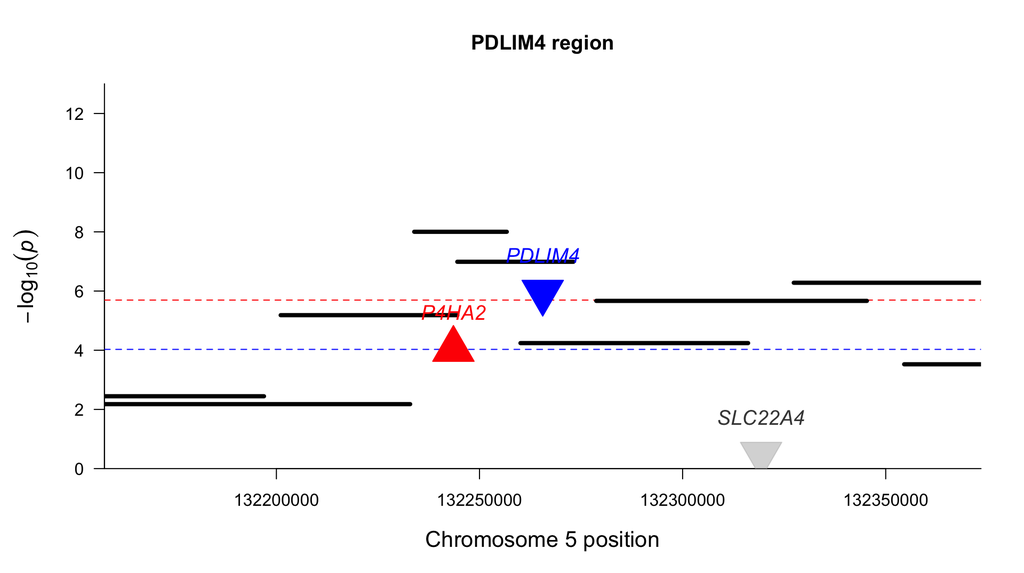

```r
i = which(fdr_sig$Gene == "PDLIM4")
scan_regression_overlap(selection_scan, MH_df_whole, fdr_sig$CHR[i], c(fdr_sig$START[i] - 1e5, fdr_sig$END[i] + 1e5), r_fdr_cut, r_b_cut, "PDLIM4 region")
```

## Figure 3

We plot TWSS-GWSS overlap, expression against time, and allele frequency against time for out two novel loci.

SLC44A5 region

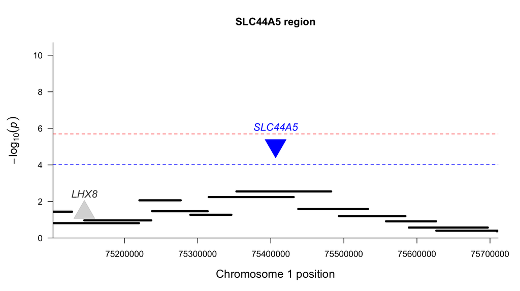

```r
i = which(fdr_sig$Gene == "SLC44A5")
scan_regression_overlap(selection_scan, MH_df_whole, fdr_sig$CHR[i], c(fdr_sig$START[i] - 1e5, fdr_sig$END[i] + 1e5), r_fdr_cut, r_b_cut, "SLC44A5 region")
```

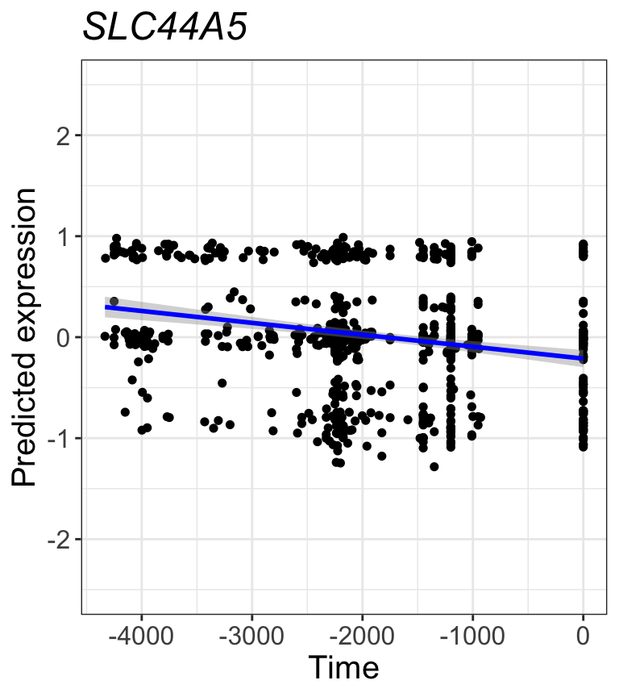

```r
expression_plot("SLC44A5")
```

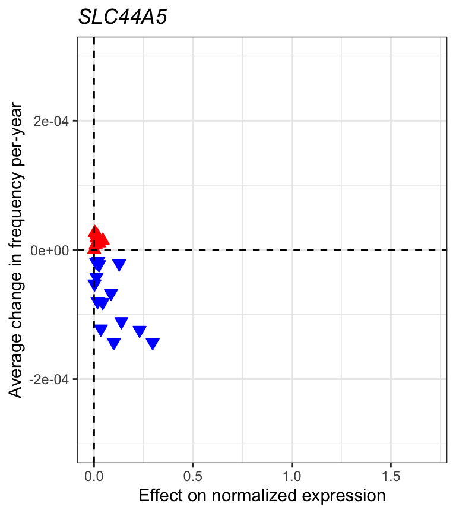

```r
af_plot_paper("SLC44A5")
```

NUP85 region

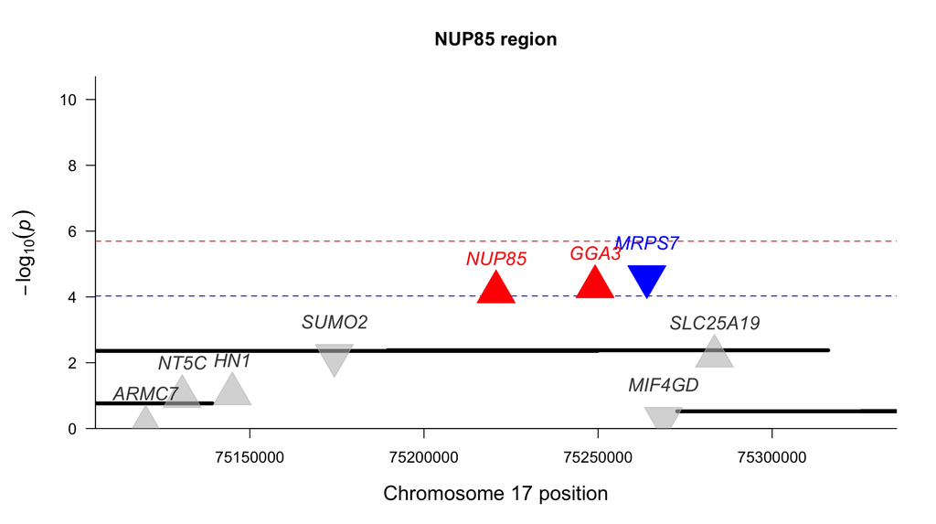

```r
i = which(fdr_sig$Gene == "NUP85")
scan_regression_overlap(selection_scan, MH_df_whole, fdr_sig$CHR[i], c(fdr_sig$START[i] - 1e5, fdr_sig$END[i] + 1e5), r_fdr_cut, r_b_cut, "NUP85 region")
```

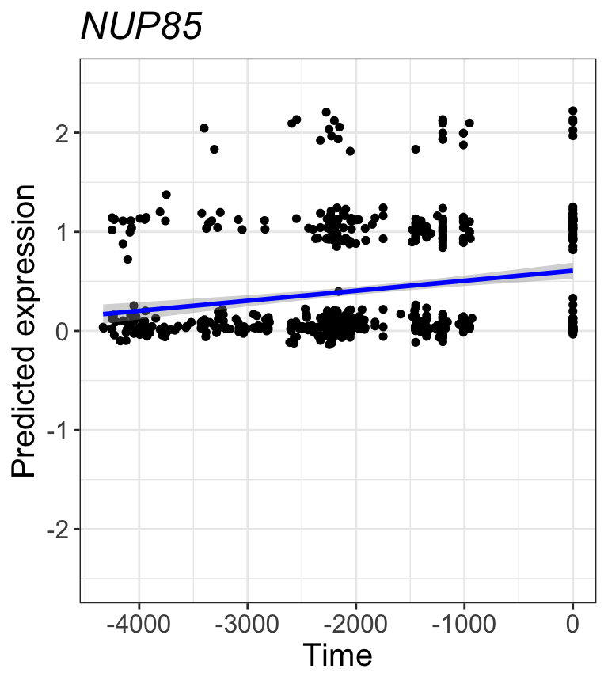

```r
expression_plot("NUP85")
```

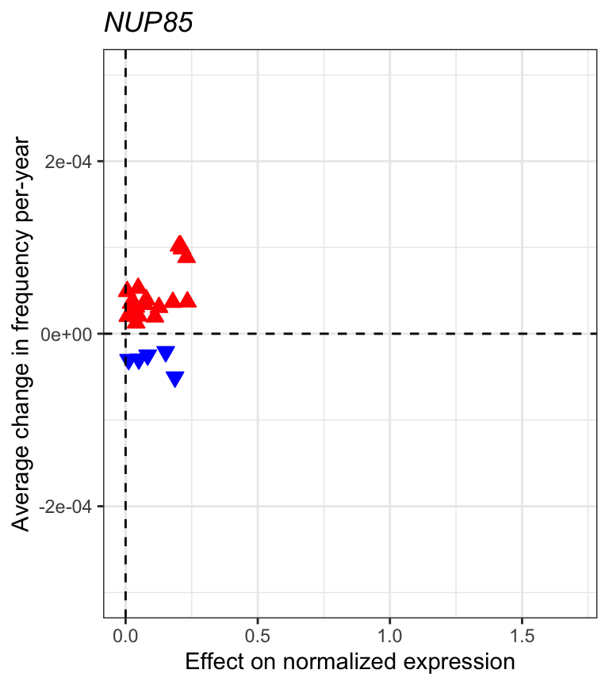

```r
af_plot_paper("NUP85")
```

## Figure 4

We begin by plotting gene-level SDS results.

We read in SDS results, filter genes with less than half of the SNPs included, and impose GC.

```r
# read file
sds = read.table("./data/SDS_results.txt.gz", header = T, sep = "\t")

# filter genes with less than half of snps included
i = which(sds$SNP.SDS/sds$SNP.total > 0.5)
sds = sds[i,]

# impose GC on SDS
p = as.numeric(sds$SDS.p)
chi_stat = qchisq(p, df = 1, lower.tail=F)
lambda = median(chi_stat)/qchisq(0.5, df=1) #inflation factor
corrected_p = pchisq(chi_stat/lambda, df=1, lower.tail=F)
sds$SDS.GC = corrected_p

sds$SDS.FDR = p.adjust(sds$SDS.GC, "fdr")
```

We generate a scatter plot of gene-level SDS and TWSS Betas.

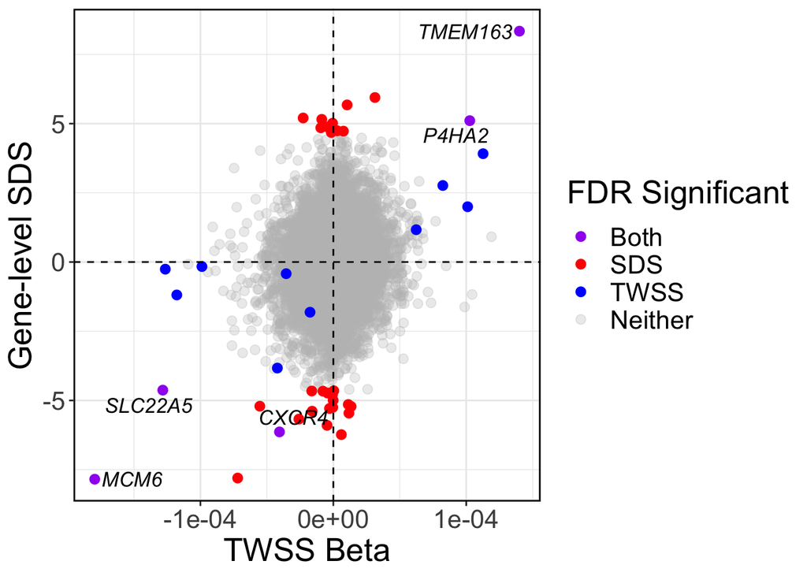

```r
df = data.frame("Gene" = sds$Gene, "SDS.GC" = -log10(sds$SDS.GC), "GC.p" = -log10(sds$GC), "GC.Beta" = sds$Beta, "SDS" = sds$SDS, "SDS.FDR" = sds$SDS.FDR)
df = merge(df, MH_df_whole[,c("Gene", "BETA", "FDR")], by = "Gene")

df$Significant = ifelse(df$SDS.FDR <= 0.05, yes = ifelse(df$FDR <= 0.05, yes = "Both", no = "SDS"), no = ifelse(df$FDR <= 0.05, yes = "TWSS", no = "Neither"))
df$o = ifelse(df$Significant == "Neither", 1, ifelse(df$Significant == "Both", 3, 2))
df$t = df$Significant == "Both"

scatter = ggplot(data = df %>% arrange(o), aes(x = BETA, y = SDS, color = Significant)) + geom_point(size=2.5) + theme_bw() + labs(x = "TWSS Beta", y = "Gene-level SDS", color = "FDR Significant") + scale_color_manual(values = c("Both" = "purple", "SDS" = "red", "TWSS" = "blue", "Neither" = alpha("gray", 0.3))) +theme(text = element_text(size = 20)) + geom_text_repel(data=subset(df, t), fontface = "italic", aes(x = BETA, y = SDS, label = Gene), color = "black", cex = 4.5) + geom_vline(xintercept = 0, linetype = "dashed") + geom_hline(yintercept = 0, linetype = "dashed") + theme(panel.border = element_rect(color = "black", fill = NA, size = 1))

scatter
```

We generate a qq-plot for the gene-level SDS results.

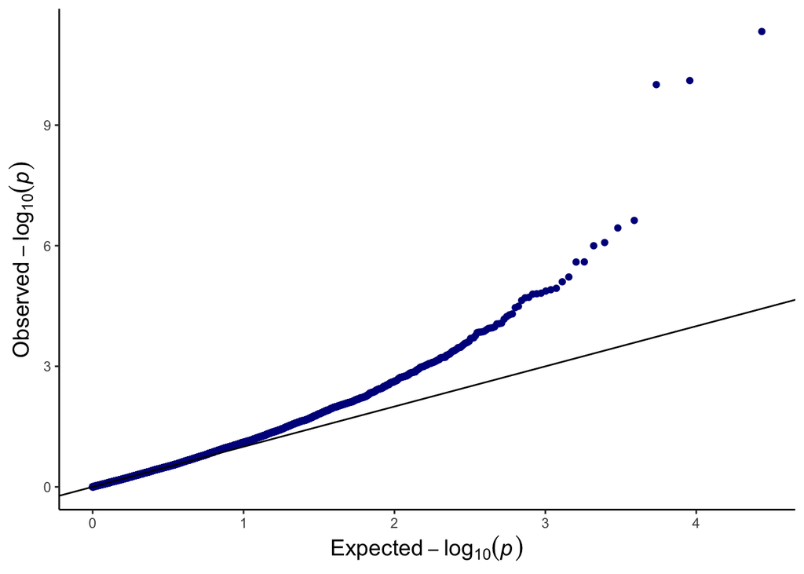

```r
p_results = as.numeric(sds$SDS.p)
p_GC = as.numeric(sds$SDS.GC)
observed_results = -log10(sort(p_results))
observed_GC = -log10(sort(p_GC))
expected = -log10(ppoints(length(p_results)))

df = data.frame("GC.Observed" = observed_GC,  "Expected" = expected)
qqlot = ggplot(data = df, aes(x = Expected, y = GC.Observed)) +
  geom_point(color = "darkblue") + geom_abline(intercept = 0, slope = 1) + labs(cex = 1.4, y = expression("Observed"-log[10](italic(p))), x = expression("Expected"-log[10](italic(p))))+ theme_bw() +  theme(axis.line = element_line(colour = "black"),
    axis.title=element_text(size=14),
    panel.grid.major = element_blank(),
    panel.grid.minor = element_blank(),
    panel.border = element_blank(),
    panel.background = element_blank())

qqlot
```

We then plot gene-level iHS results.

We read in iHS results, filter genes with less than half of the SNPs included, and impose GC.

```r
# read file
iHS = read.table("./data/iHS_results.txt.gz", header = T, sep = "\t")
iHS = na.omit(iHS)

# filter genes with less than half of snps included
i = which(iHS$SNP.iHS/iHS$SNP.total > 0.5)
iHS = iHS[i,]

# impose GC on SDS
p = as.numeric(iHS$iHS.p)
chi_stat = qchisq(p, df = 1, lower.tail=F)
lambda = median(chi_stat)/qchisq(0.5, df=1) #inflation factor
corrected_p = pchisq(chi_stat/lambda, df=1, lower.tail=F)
iHS$iHS.GC = corrected_p
iHS$iHS.FDR = p.adjust(iHS$iHS.GC, "fdr")
```

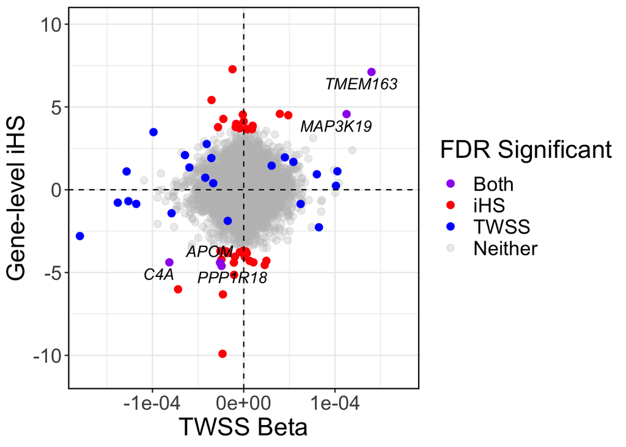

```r
df = data.frame("Gene" = iHS$Gene, "iHS.GC" = -log10(iHS$iHS.GC), "GC.p" = -log10(iHS$GC), "GC.Beta" = iHS$Beta, "iHS" = iHS$iHS, "iHS.FDR" = iHS$iHS.FDR)
df = merge(df, MH_df_whole[,c("Gene", "BETA", "FDR")], by = "Gene")

df$Significant = ifelse(df$iHS.FDR <= 0.05, yes = ifelse(df$FDR <= 0.05, yes = "Both", no = "iHS"), no = ifelse(df$FDR <= 0.05, yes = "TWSS", no = "Neither"))
df$o = ifelse(df$Significant == "Neither", 1, ifelse(df$Significant == "Both", 3, 2))
df$t = df$Significant == "Both"

scatter = ggplot(data = df %>% arrange(o), aes(x = BETA, y = iHS, color = Significant)) + geom_point(size=2.5) + theme_bw() + labs(x = "TWSS Beta", y = "Gene-level iHS", color = "FDR Significant") + scale_color_manual(values = c("Both" = "purple", "iHS" = "red", "TWSS" = "blue", "Neither" = alpha("gray", 0.3))) +theme(text = element_text(size = 20)) + geom_text_repel(data=subset(df, t), aes(y = iHS, x = BETA, label = Gene, fontface = "italic"), color = "black", cex = 4.5) + coord_cartesian(ylim = c(-11,10), xlim = c(-1.75e-4, 1.75e-4)) + geom_vline(xintercept = 0, linetype = "dashed") + geom_hline(yintercept = 0, linetype = "dashed") + theme(panel.border = element_rect(color = "black", fill = NA, size = 1))

scatter
```

We generate a qq-plot for the gene-level iHS results.

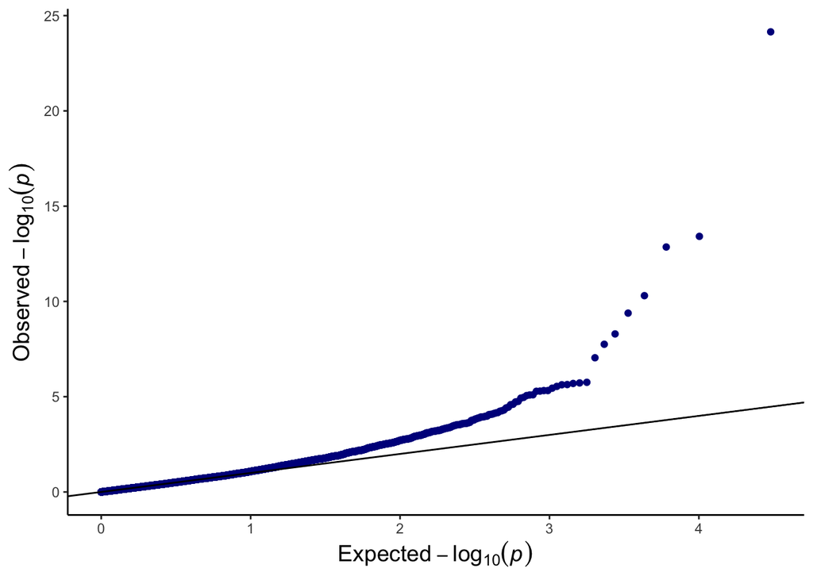

```r
p_results = as.numeric(iHS$iHS.p)
p_GC = as.numeric(iHS$iHS.GC)
observed_results = -log10(sort(p_results))
observed_GC = -log10(sort(p_GC))
expected = -log10(ppoints(length(p_results)))

df = data.frame("GC.Observed" = observed_GC,  "Expected" = expected)
qqlot = ggplot(data = df, aes(x = Expected, y = GC.Observed)) +
  geom_point(color = "darkblue") + geom_abline(intercept = 0, slope = 1) + labs(cex = 1.4, y = expression("Observed"-log[10](italic(p))), x = expression("Expected"-log[10](italic(p))))+ theme_bw() +  theme(axis.line = element_line(colour = "black"),
    axis.title=element_text(size=14),
    panel.grid.major = element_blank(),
    panel.grid.minor = element_blank(),
    panel.border = element_blank(),
    panel.background = element_blank())

qqlot
```